# Business Dynamics Database (BDS)

# Overview

> BDS provides annual measures of business dynamics (such as job creation and destruction, establishment births and deaths, and firm startups and shutdowns) for the economy overall and aggregated by establishment and firm characteristics.

The revision available in `pubdata` is 2023. Some 2022 tables are also included and should be available as long as source files exist at original URLs.

Data source links.

- [Home](https://www.census.gov/programs-surveys/bds.html)
- [CSV datasets](https://www.census.gov/data/datasets/time-series/econ/bds/bds-datasets.html)
- [Methodology](https://www.census.gov/programs-surveys/bds/documentation/methodology.html)
- [Codebook and Glossary](https://www.census.gov/programs-surveys/bds/documentation/codebook-glossary.html)

# Tables

List of all tables in the collection.

|  | key | description | rows | cols |
| --- | --- | --- | --- | --- |
| 1 | 2022_met | BDS by metro/non-metro, 2022 revision | 180 | 49 |
| 2 | 2022_st_cty | BDS by county, 2022 revision | 146295 | 50 |
| 3 | 2022_st_cty_sec | BDS by county by sector, 2022 revision | 2779605 | 51 |
| 4 | 2022_met_ea | BDS by metro/non-metro and establishment age, 2022 revision | 2160 | 50 |
| 5 | 2022_met_eac | BDS by metro/non-metro and establishment age coarse, 2022 revision | 900 | 50 |
| 6 | 2022_met_ezc | BDS by metro/non-metro and establishment size coarse, 2022 revision | 540 | 50 |
| 7 | 2022_met_sec | BDS by metro/non-metro and NAICS sector, 2022 revision | 3420 | 50 |
| 8 | 2023 | BDS Economy-wide, 2023 revision | 46 | 48 |
| 9 | 2023_fa | BDS Firm Age, 2023 revision | 552 | 49 |
| 10 | 2023_fac | BDS Firm Age Coarse, 2023 revision | 230 | 49 |

[output cut: 187 more lines]

# Columns

Listing of all columns in each table.

|  | key | column | type | desc | na | unique |
| --- | --- | --- | --- | --- | --- | --- |
| 1 | 2022_met | year | integer | Record year | 0 | 45 |
| 2 | 2022_met | metro | character | Establishments located in Metropolitan or Micropolitan Statistical Areas are in cells designated with “M”, while those in non-metropolitan areas are aggregated into cells designated with “N”. Cells de… | 0 | 4 |
| 3 | 2022_met | firms | integer | A simple count of the number of firms in the cell. For state level tables, a firm with establishments in multiple states be counted multiple times, once in each state, irrespective of the portion of t… | 3 | 168 |
| 4 | 2022_met | firms_f | character | "firms" supression flag. "D": fewer than three firms, "S": identified data quality concerns, "X": structurally missing or structurally zero, "N": cannot be calculated. | 177 | 2 |
| 5 | 2022_met | estabs | integer | A simple count of the number of establishments in the cell. | 3 | 169 |
| 6 | 2022_met | estabs_f | character | "estabs" supression flag. "D": fewer than three firms, "S": identified data quality concerns, "X": structurally missing or structurally zero, "N": cannot be calculated. | 177 | 2 |
| 7 | 2022_met | emp | integer | Paid employment consists of full and part-time employees, including salaried officers and executives of corporations, who are on the payroll in the pay period including March 12. Included are employee… | 3 | 177 |
| 8 | 2022_met | emp_f | character | "emp" supression flag. "D": fewer than three firms, "S": identified data quality concerns, "X": structurally missing or structurally zero, "N": cannot be calculated. | 177 | 2 |
| 9 | 2022_met | denom | integer | Davis-Haltiwanger-Schuh (DHS) denominator. For time t, denom is the average of employment for times t and t-1. This variable attempts to prevent transitory shocks from creating a bias to the relations… | 4 | 177 |
| 10 | 2022_met | denom_f | character | "denom" supression flag. "D": fewer than three firms, "S": identified data quality concerns, "X": structurally missing or structurally zero, "N": cannot be calculated. | 176 | 2 |

[output cut: 9914 more lines]

# Examples

Author: Diveesha Vanchireddy

## Metro vs non-metro exit rates

How do the exit rates of establishments differ pre and post covid in metro vs non metros?

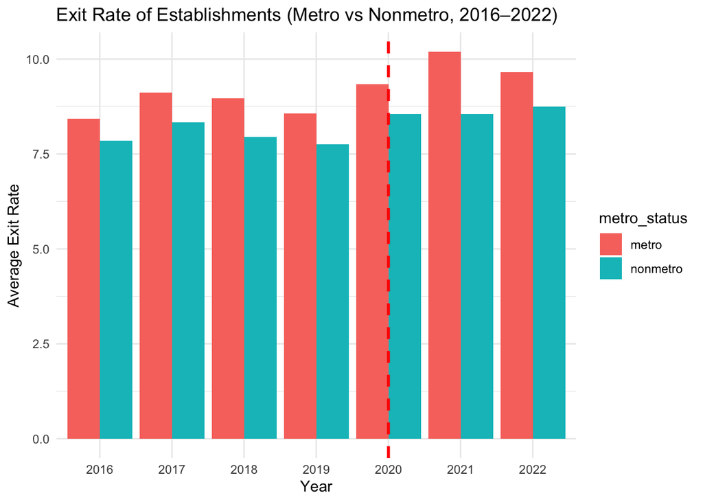

```r
# load the processed metro/nonmetro dataset
df <- pubdata::get("bds", "2022_met") %>%
  mutate(
    year = as.integer(year),
    estabs_exit_rate = as.numeric(estabs_exit_rate),
    metro_status = case_when(
      metro == "M" ~ "metro",
      metro == "N" ~ "nonmetro",
      TRUE ~ NA_character_
    ),
    covid_period = ifelse(year < 2020, "pre_covid", "post_covid")
  ) %>%
  filter(year >= 2016 & year <= 2022, !is.na(metro_status))

# summarise
summary_df <- df %>%
  group_by(year, metro_status) %>%
  summarise(avg_exit_rate = mean(estabs_exit_rate, na.rm = TRUE), .groups = "drop")

# plot
ggplot(summary_df, aes(x = factor(year), y = avg_exit_rate, fill = metro_status)) +
  geom_col(position = "dodge") +
  geom_vline(
    xintercept = which(sort(unique(summary_df$year)) == 2020),
    linetype = "dashed", color = "red", size = 1
  ) +
  labs(
    title = "Exit Rate of Establishments (Metro vs Nonmetro, 2016–2022)",
    y = "Average Exit Rate",
    x = "Year"
  ) +
  theme_minimal()
```

The data indicate that metro establishments were more vulnerable to pandemic-related shocks, hence we see a larger establishment exit rate. Nonmetro establishments showed a smaller relative increase.This suggests that rural economies may have been somewhat more protected from pandemic disruptions which is an important factor to consider when working with business dynamics in rural areas.

## Establishment exit and job creation

How does the job creation rate differ with establishment exit rate?

```r
# Load and preprocess correctly
df <- pubdata::get("bds", "2022_met") %>%
  mutate(
    job_creation_rate = as.numeric(job_creation_rate),
    establishment_exit_rate = as.numeric(estabs_exit_rate),
    metro_status = case_when(
      metro == "M" ~ "metro",
      metro == "N" ~ "nonmetro",
      TRUE ~ NA_character_
    ),
  ) %>%
  filter(
    metro_status %in% c("metro", "nonmetro"),  # keep only metro and nonmetro
    !is.na(job_creation_rate),
    !is.na(establishment_exit_rate)
  )

# Summarize the relationship (linear regression by metro status)
relationship_summary <- df %>%
  group_by(metro_status) %>%
  do(tidy(lm(establishment_exit_rate ~ job_creation_rate, data = .))) %>%
  filter(term == "job_creation_rate") %>%
  select(metro_status, estimate, std.error, p.value)

print(relationship_summary)
```

```
# A tibble: 2 × 4
# Groups:   metro_status [2]
  metro_status estimate std.error      p.value
  <chr>           <dbl>     <dbl>        <dbl>
1 metro           0.236    0.0541 0.0000812
2 nonmetro        0.395    0.0565 0.0000000133
```

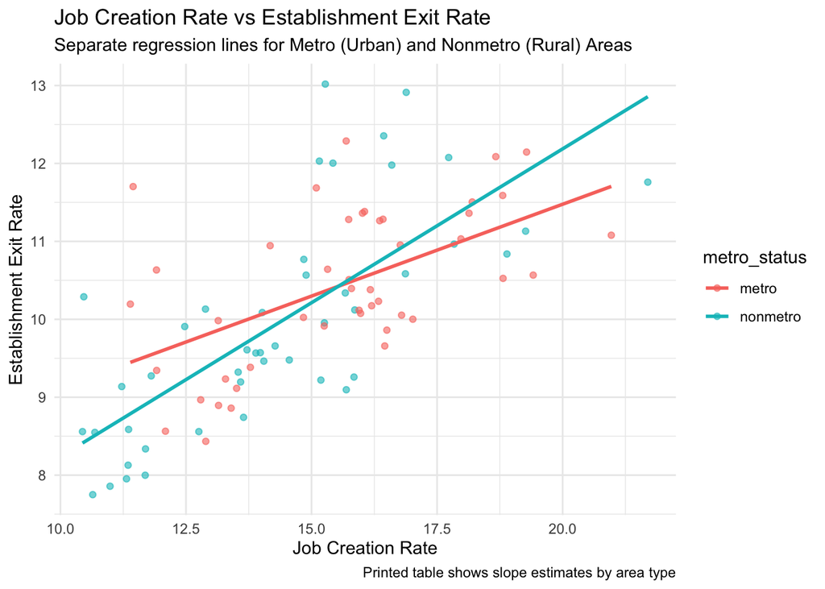

```r
# Scatterplot with regression lines
ggplot(df, aes(x = job_creation_rate, y = establishment_exit_rate, color = metro_status)) +
  geom_point(alpha = 0.6) +
  geom_smooth(method = "lm", se = FALSE) +
  labs(
    title = "Job Creation Rate vs Establishment Exit Rate",
    subtitle = "Separate regression lines for Metro (Urban) and Nonmetro (Rural) Areas",
    x = "Job Creation Rate",
    y = "Establishment Exit Rate",
    caption = "Printed table shows slope estimates by area type"
  ) +
  theme_minimal()
```

The linear model above shows that in there is positive relationship between job creation rate and the establishment exit rate in both metro areas and non metro areas but the slope of non metro areas is higher than metro areas which signifies that there is higher instability in rural areas compared to urban areas.

## Jobs in metro vs rural areas

What is the share of total employment in rural vs metro areas?

```r
df_met <- pubdata::get("bds", "2022_met") %>%
  mutate(
    emp = as.numeric(emp),  # total employment
    metro_status = case_when(
      metro == "M" ~ "metro",
      metro == "N" ~ "nonmetro",
      TRUE ~ NA_character_
    )
  ) %>%
  filter(metro_status %in% c("metro","nonmetro"))

# Summed employment by type
emp_summary <- df_met %>%
  group_by(metro_status) %>%
  summarise(total_emp = sum(emp, na.rm = TRUE), .groups = "drop")

# Add share
total_us_emp <- sum(emp_summary$total_emp, na.rm = TRUE)

emp_summary %>%
  mutate(share = total_emp / total_us_emp)
```

| metro_status | total_emp | share |
| --- | --- | --- |
| metro | 4498865989 | 0.9607757 |
| nonmetro | 183668995 | 0.0392243 |

## Metro vs rural growth

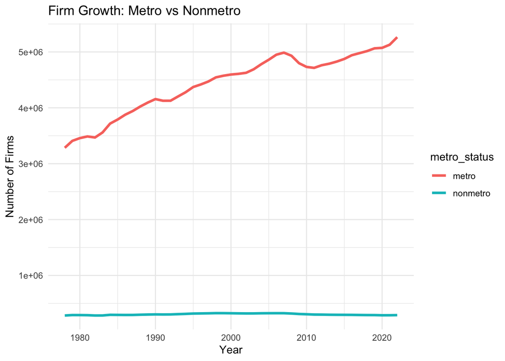

```r
# Load data (replace year key if needed)
df <- pubdata::get("bds", "2022_met") %>%
  mutate(
    metro_status = case_when(
      metro == "M" ~ "metro",
      metro == "N" ~ "nonmetro",
      TRUE ~ NA_character_
    )
  ) %>%
  filter(!is.na(metro_status))

# Summarize total firms and employment by metro status and year
summary_df <- df %>%
  group_by(year, metro_status) %>%
  summarise(
    total_firms = sum(firms, na.rm = TRUE),
    total_emp   = sum(emp, na.rm = TRUE),
    .groups = "drop"
  )

# Plot trends
p1 <- ggplot(summary_df, aes(x = year, y = total_firms, color = metro_status)) +
  geom_line(size = 1.2) +
  labs(title = "Firm Growth: Metro vs Nonmetro", y = "Number of Firms", x = "Year") +
  theme_minimal()

p2 <- ggplot(summary_df, aes(x = year, y = total_emp, color = metro_status)) +
  geom_line(size = 1.2) +
  labs(title = "Employment Growth: Metro vs Nonmetro", y = "Total Employment", x = "Year") +
  theme_minimal() + expand_limits(y=0)

# ---- Growth rates (indexed to first year) ----
summary_growth <- summary_df %>%
  group_by(metro_status) %>%
  arrange(year) %>%
  mutate(
    firms_index = total_firms / first(total_firms) * 100,
    emp_index   = total_emp / first(total_emp) * 100
  ) %>%
  ungroup()

p3 <- ggplot(summary_growth, aes(x = year, y = firms_index, color = metro_status)) +
  geom_line(size = 1.2) +
  labs(title = "Firm Growth Rate: Indexed to First Year", y = "Index (First Year = 100)", x = "Year") +
  theme_minimal() +
  expand_limits(y = 0)

p4 <- ggplot(summary_growth, aes(x = year, y = emp_index, color = metro_status)) +
  geom_line(size = 1.2) +
  labs(title = "Employment Growth Rate: Indexed to First Year", y = "Index (First Year = 100)", x = "Year") +
  theme_minimal() +
  expand_limits(y = 0)


print(p1)
```

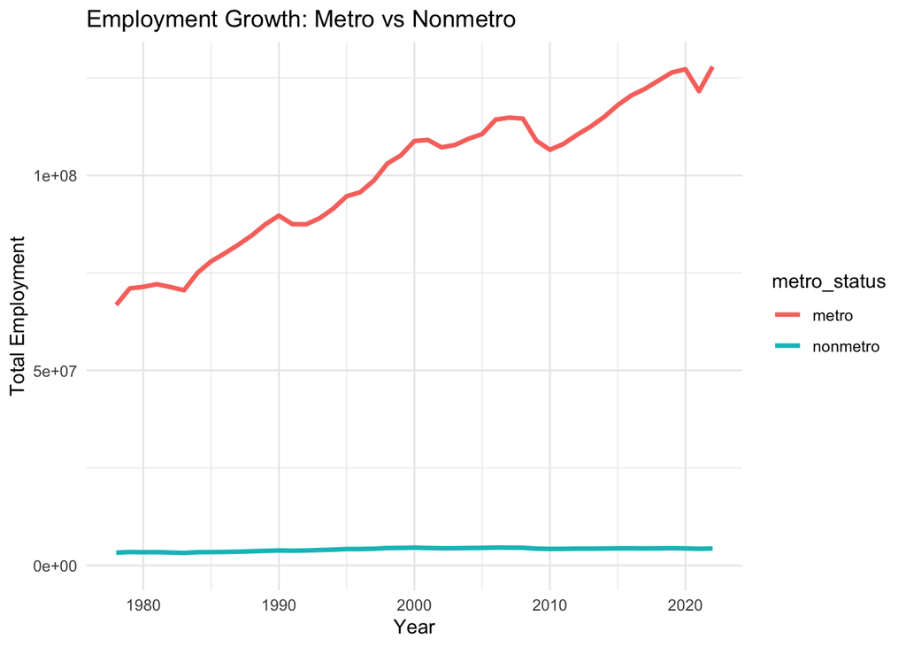

```r
print(p2)
```

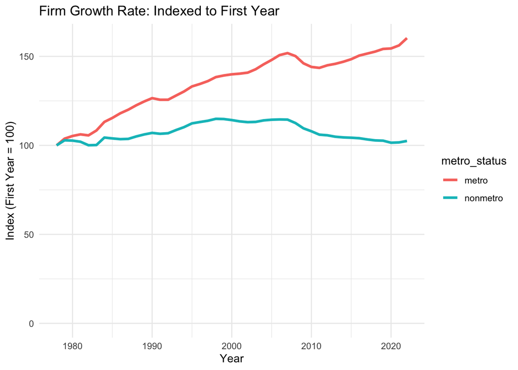

```r
print(p3)
```

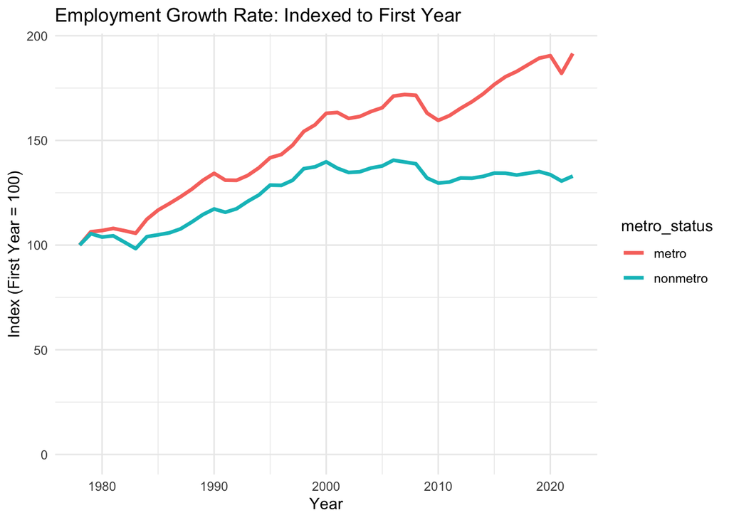

```r
print(p4)
```

```r
# Compute growth rates pre vs post COVID
growth_summary <- summary_df %>%
  group_by(metro_status) %>%
  summarise(
    firms_growth = (last(total_firms) - first(total_firms)) / first(total_firms) * 100,
    emp_growth   = (last(total_emp) - first(total_emp)) / first(total_emp) * 100,
    .groups = "drop"
  )

print(growth_summary)
```

```
# A tibble: 2 × 3
  metro_status firms_growth emp_growth
  <chr>               <dbl>      <dbl>
1 metro               60.3        91.5
2 nonmetro             2.48       33.0
```

## Multi-establishment firms

Do rural areas have more single establishment firms vs multi-establishment firms?

```r
df <- pubdata::get("bds", "2022_met") %>%
  mutate(
    metro_status = case_when(
      metro == "M" ~ "metro",
      metro == "N" ~ "nonmetro",
      TRUE ~ NA_character_
    )
  ) %>%
  filter(!is.na(metro_status))

# Calculate single vs multi establishment counts
df_summary <- df %>%
  group_by(year, metro_status) %>%
  summarise(
    total_firms = sum(firms, na.rm = TRUE),
    total_estabs = sum(estabs, na.rm = TRUE),
    .groups = "drop"
  ) %>%
  mutate(
    single_estab_firms = total_firms,                     # every firm has at least one estab
    multi_estab_extra  = total_estabs - total_firms,      # establishments beyond 1 per firm
    share_single_estab = total_firms / total_estabs * 100 # % of establishments that are single-unit
  )

print(df_summary)
```

```
# A tibble: 90 × 7
    year metro_status total_firms total_estabs single_estab_firms
   <int> <chr>              <int>        <int>              <int>
 1  1978 metro            3284606      4005231            3284606
 2  1978 nonmetro          283387       315444             283387
 3  1979 metro            3408383      4155226            3408383
 4  1979 nonmetro          291424       324013             291424
 5  1980 metro            3457634      4221684            3457634
 6  1980 nonmetro          290968       324005             290968
 7  1981 metro            3487558      4281982            3487558
 8  1981 nonmetro          289157       323219             289157
 9  1982 metro            3468666      4293546            3468666
10  1982 nonmetro          283596       318419             283596
# ℹ 80 more rows
# ℹ 2 more variables: multi_estab_extra <int>, share_single_estab <dbl>
```

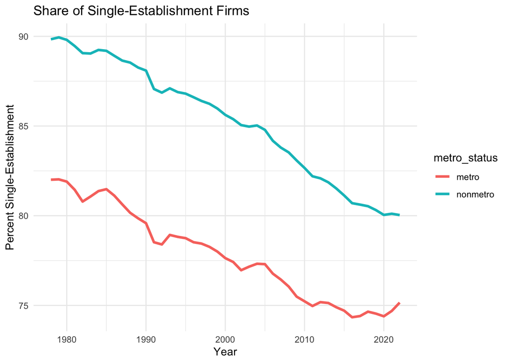

```r
# Visualization: share of single-unit establishments
ggplot(df_summary, aes(x = year, y = share_single_estab, color = metro_status)) +
  geom_line(size = 1.2) +
  labs(
    title = "Share of Single-Establishment Firms",
    y = "Percent Single-Establishment",
    x = "Year"
  ) +
  theme_minimal()
```

Rural areas continue to depend more on small, independent firms, while metros are more dominated by multi-location businesses. But both areas are trending toward fewer single-establishment firms over time, reflecting a national shift toward consolidation and chain expansion.